# Data Vs. Dogma: Maternal Wellness Conditions and Abortion Policy per State

Introduction

## Problem & Objectives

Abortion policy now varies significantly across states, reflecting the political leanings of their governments. Some states have enacted sweeping bans or severe restrictions, while others have worked to protect or expand access. This disparity has led to profound public health implications, as the ability to access abortion services is intrinsically tied to maternal and child health outcomes. A visualization of the geographic variability is shown below.

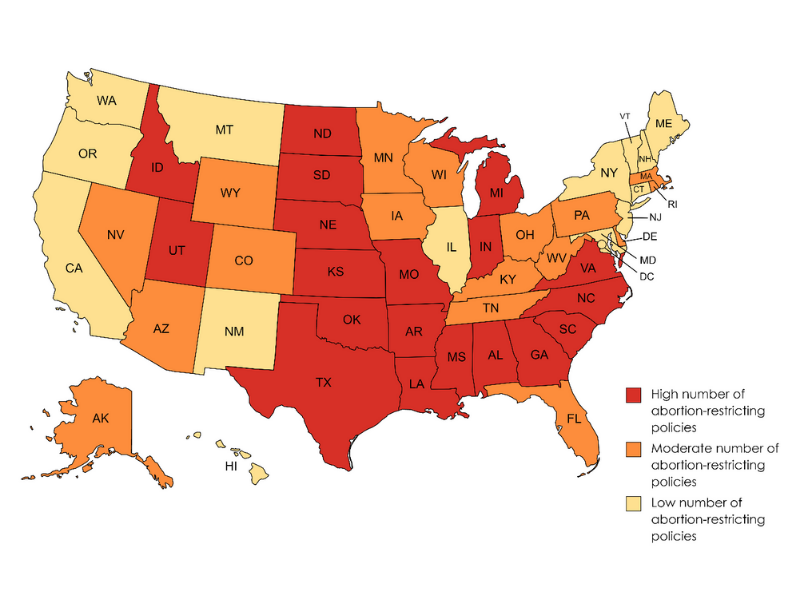

Traditionally, debates around abortion have been framed in moral and ethical terms, which often overshadow empirical evidence and data. While ethical considerations are important, this perspective tends to neglect the measurable impact of abortion policy on health and well-being. This research project aims to take a data-driven approach to objectively examine how abortion policy affects maternal wellness across the United States.

Central research question: *How do state-level abortion policies impact maternal well-being, and what broader factors contribute to state-to-state variation in these outcomes?*

To answer this question, public health data will be analyzed at the state level using abortion policy as a key variable. The aim is to provide a more concrete, evidence-based understanding of the relationship between abortion policy and maternal health. Ultimately, this research seeks to contribute to the broader policy discourse by grounding it in the lived experiences and health outcomes of women.

## Context & Case Studies

Since the reversal of Roe v. Wade in 2022, numerous stories have emerged illustrating the devastating impact of abortion bans on women and children’s health. For example, a study by Stevenson (2021) projected a 7% increase in maternal mortality in the first year following widespread abortion bans, with the rate rising to 23% in the subsequent year (Stevenson 2021). These findings highlight the immediate and severe health risks associated with restrictive abortion policies. Notably, vulnerable populations, including racial minorities and those with low socioeconomic status, are disproportionately affected.

The effects of the Dobbs decision have also had less direct negative impacts on women. Adkins et. al found an 11% increase in children placed in the foster care system in states that instituted TRAP (Targeted Regulation of Abortion Providers) laws (Adkins et al. 2024). Wallace et. al. find a 3.4% increase in the likelihood that women fall victim to domestic partner violence with each additional implementation of a TRAP law (Wallace et al. 2024). These findings illustrate how abortion policy has ripple associations beyond immediate impacts on women’s health.

While maternal mortality is one critical measure, it is only one piece of the larger picture. Well-being encompasses a wide range of factors, including access to prenatal care, economic stability, and the mental health of mothers and families. These indicators often vary widely across states, driven by differences in healthcare infrastructure, economic resources, and social support.

## Research Questions

Data science question: what conditions cause variation in maternal wellness by state?

1. What is the association of abortion policy and infant/maternal mortality?
2. What is the association of race and infant/maternal mortality?
3. What is the association of healthcare quality and abortion policy?
4. What is the association of healthcare quality and infant and maternal mortality?
5. What is the association between mandated policy (for example parental leave) and abortion policy?
6. Do states with policies that make conditions for women having babies more difficult, tend to have higher infant and maternal mortality rates?
   1. Parental leave
   2. Abortion laws
7. Do states with stricter maternal condition policies have worse healthcare?

[output not shown]

## References

Adkins, Savannah, Noa Talmor, Molly H White, Caryn Dutton, and Ashley L O’Donoghue. 2024. “Association Between Restricted Abortion Access and Child Entries into the Foster Care System.” *JAMA Pediatrics* 178 (1): 37–44.

Stevenson, Amanda Jean. 2021. “The Pregnancy-Related Mortality Impact of a Total Abortion Ban in the United States: A Research Note on Increased Deaths Due to Remaining Pregnant.” *Demography* 58 (6): 2019–28. https://doi.org/10.1215/00703370-9585908.

Wallace, Maeve E, Charles Stoecker, Sydney Sauter, and Dovile Vilda. 2024. “States’ Abortion Laws Associated with Intimate Partner Violence–Related Homicide of Women and Girls in the US, 2014–20: Study Examines the Association of Abortion Laws to Intimate Partner Violence of Women and Girls.” *Health Affairs* 43 (5): 682–90.